# front_range_model_update

Spencer Rhea

7/24/2020

# Intro

### This is pretty much the same information I sent y’all the other week but with a few updates. First I re-ran the model for the front range but excluded Boulder and Greeley so that we can better focus on the other cities. I also changed the graphs to only include estimates in the model that are significant.

# Data Availability

## Block groups within 3km of a water body

### Yes indicates block groups within 3km of water bodies and non are block groups not within 3km of waterbodies. The horizontal lines in the middle of each violin plot show the median value for that group.

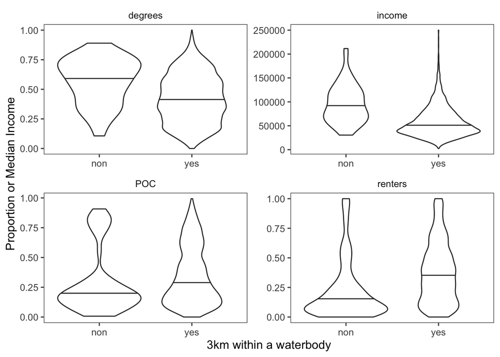

## E.coli data availability

### Of sites within 3km of a waterbody. This indicates if waterways are being monitored for ecoli or not.

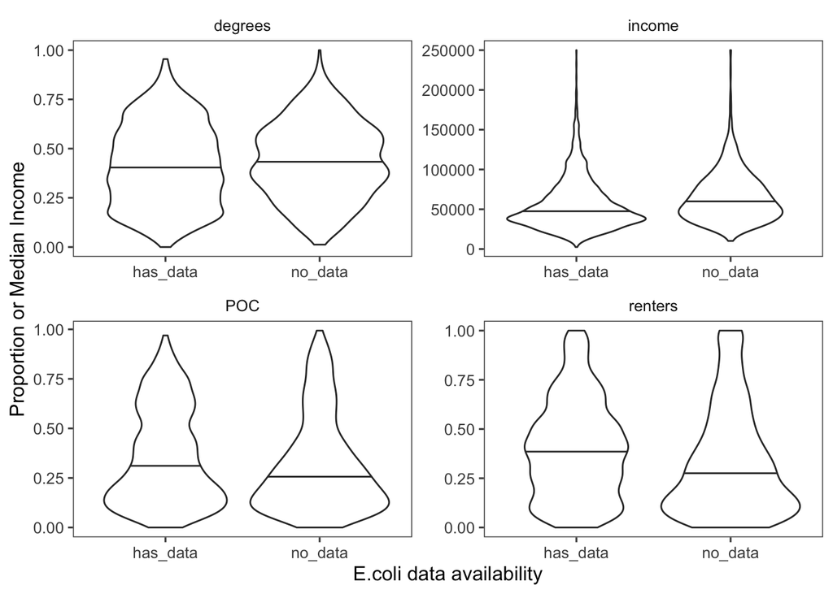

# Front Range Model

### I re-ran the model but only for Fort Collins, Denver, Colorado Springs, and Pueblo. The patterns are especially the same as when we ran the model for the whole front range.

## Compare by demographics

### This is the same graph as last week but only with the model estimates that are below 0.05. The horizontal black lines indicate the global front range model estimate and the red dots show the estimate for each city that have a p value below 0.05. We see that a red dot above the black line shows that that variable has a greater affect in that city relative to the rest of the front range.

### Note that Fort Collins had no estimates below 0.05 for all demographic variables. Also, income was not significant for the whole front range model but income was significant in Colorado Springs.

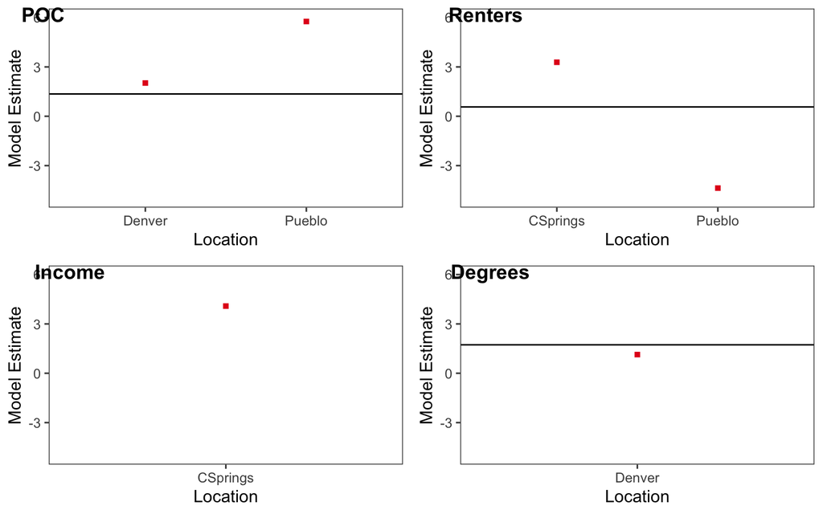

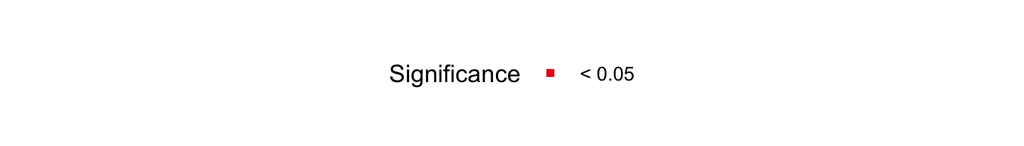

## Compare by city

### Again, this is the same information from above but grouped by City. Blue dots show the significant estimates for the front range model, and black dots show significant estimates for each city. With the specific demographic variable on the x axis.

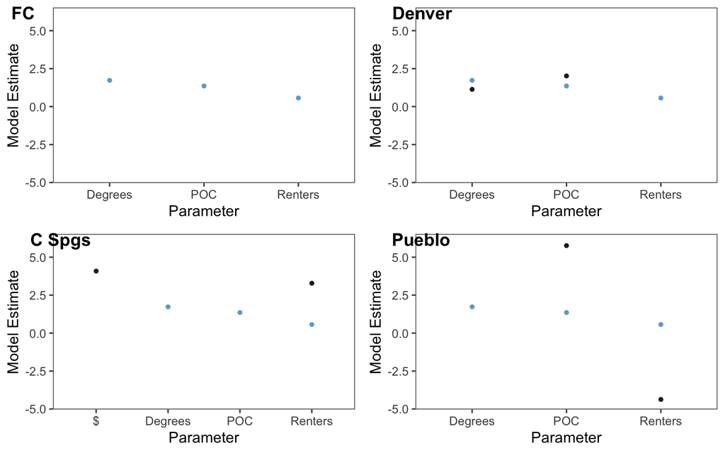

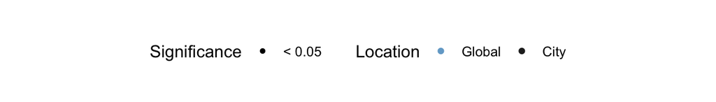

# Landcover and WWTP

### These are the same as last time. Each graph shows the percent of the watershed that is covered by the various land covers. The black dots show the location and magnitude (on the right axis) of E.coli concentration at monitoring locations. And the vertical lines show the locations of waste water treatment plants.

## Poudre

### Fort Collins Metro Areas

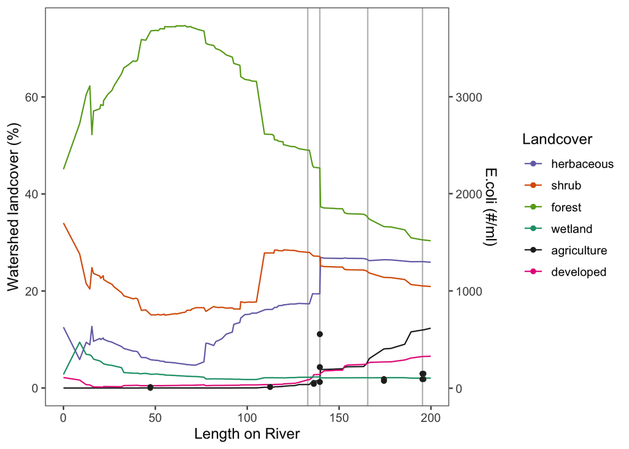

## Big Thompson

### Fort Collins Metro Areas

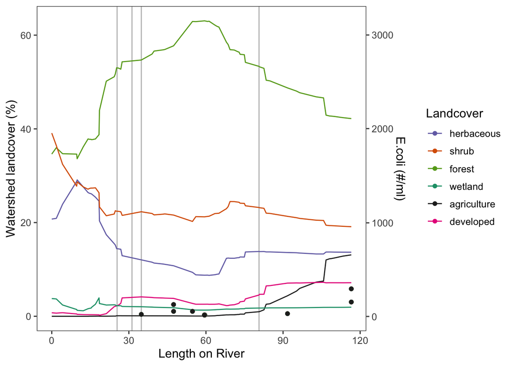

## South Platte

### Denver Metro Area

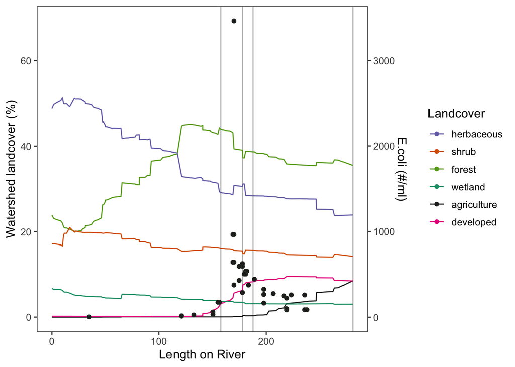

## Monument Creek

### Colorado Springs Metro Area

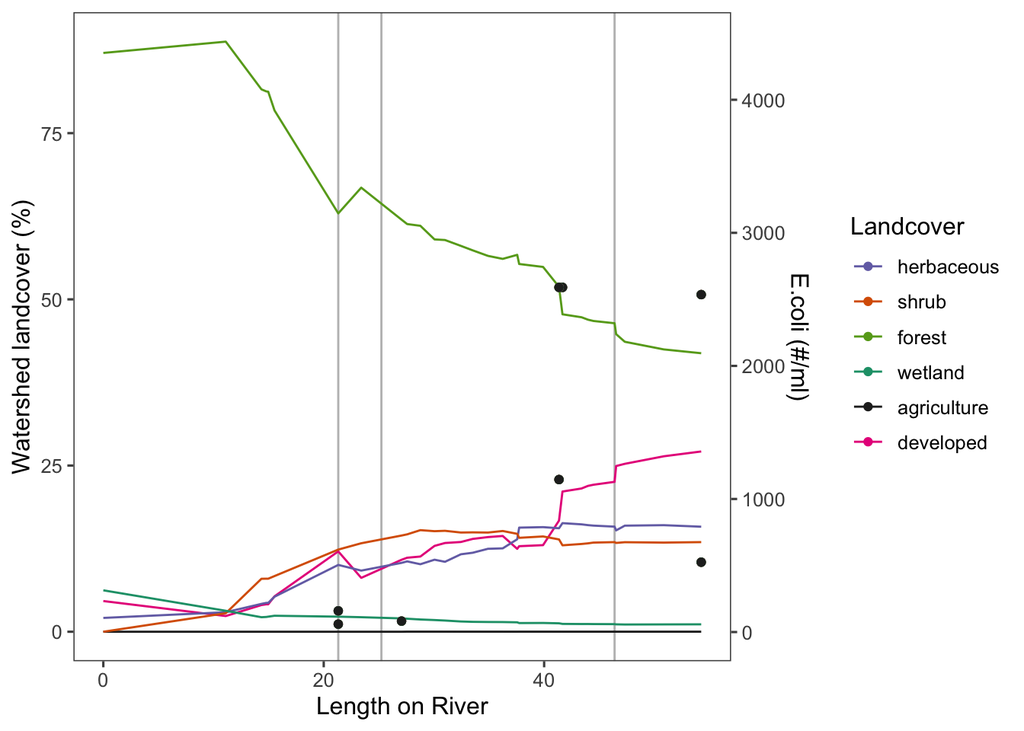

## Fountain Creek

### Colorado Springs and Pueblo Metro Areas

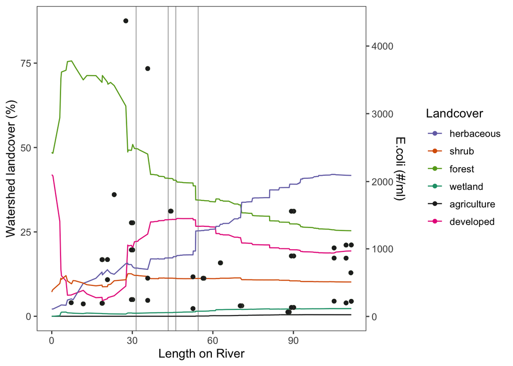

## Arkansas

### This river may not be comparable to the other because of its size. It also has a large reservoir just above Pueblo.

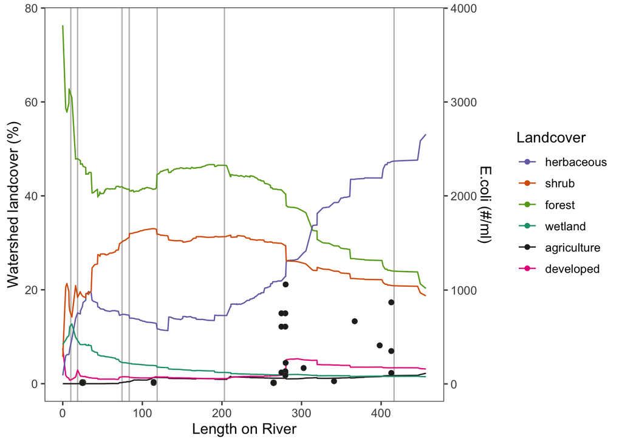